# Analysis of Dispatch Times for Vancomycin Levels in HVI

Brian Gulbis

April 18, 2017

# Problem Overview

In CVICU, approximately 40% of vancomycin levels are being collected inappropriately, and this rate has been increasing from April to December 2016. Approximately 9% of ordered levels are never collected.

Inappropriately collected is defined as being collected more than 60 minutes from the scheduled collection time, or more than 120 minutes for Early AM levels

Inappropriately drawn levels lead to inaccurate dosing and treatment decisions, which may result in undertreating infections, increased antimicrobial resistance, and increased risk of adverse effects.

# Process

1. Provider places the order for the vancomycin level, specifying a priority (Routine, Stat, Timed Study) and a date/time for collection.

   This includes orders for both the Vancomycin Level and Vancomycin Level Trough labs.
2. Care4 dispatches a task for nursing to collect the lab specimen.

   Nurses do not receive notification of the lab collection task until the task has been dispatched.
3. Nurse reviews their task list and sees the lab collection task.

   Nurses are expected to review the chart/Care4 for new orders every two hours.
4. Nurse collects the lab specimen and sends it to the lab.

# Key Finding

Distribution of time from task dispatch to scheduled collection by order priority. Each bar represents a 15-minute increment. There is large variation in the amount of advanced notification a nurse has before the lab is due to be collected.

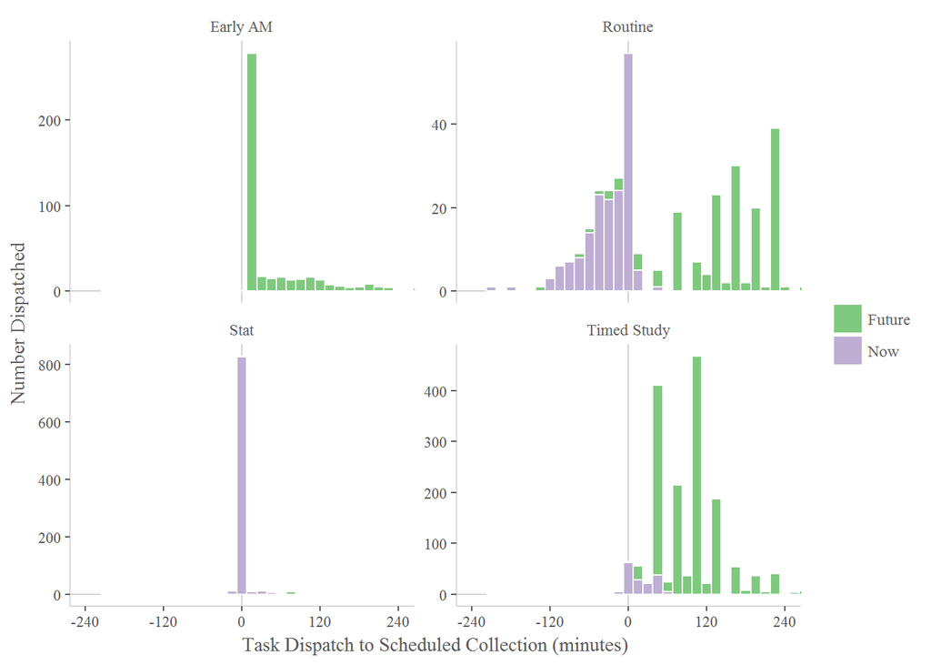

# Assessment

It appears that Stat orders dispatch immediately, whereas Routine (which includes orders for Early AM) and Timed Study orders dispatch a variable amount of time relative to the scheduled collection time. Most Timed Study orders are dispatching at either 45, 75, 105, or 135 minutes prior to the scheduled collection time. Routine orders scheduled for future collection dispatch on the same 30-minute interval as Timed Study but extend further out, while many Routine orders due to be collected *now* do not dispatch until up to 120 minutes **after** the lab was supposed to be collected. Most Early AM tasks dispatch 15 minutes prior to the scheduled collection time. The variability in task dispatching may present a challenge for nurses to draw time-sensitive labs in a timely manner if they do not receive enough notification to draw the lab.

Distribution of time from task dispatch to scheduled collection for Future vs. Now orders

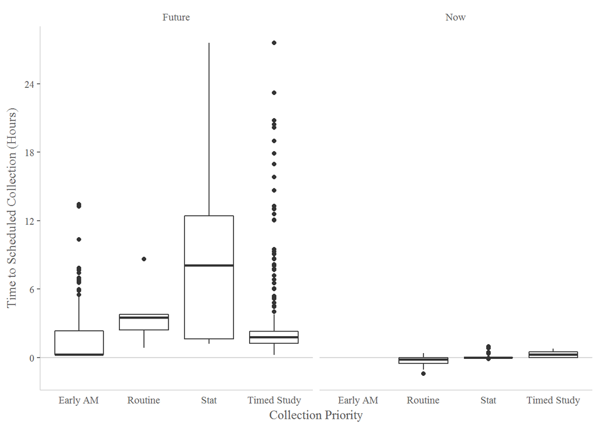

# Explanation

Orders are placed in a queue and batch dispatch at set times throughout the day. The only exception to this are Stat orders which dispatch immediately. Early AM orders primarily dispatch daily at 03:00, while Routine and Timed Study orders dispatch every 2 hours from 03:00 until 23:00. The major difference between Routine and Timed Study is that Routine orders will always wait until the next batch time to dispatch, whereas if a Timed Study is due to be collected prior to the next batch time, then the task will dispatch immediately.

Hour of day when Routine and Timed Study orders dispatch

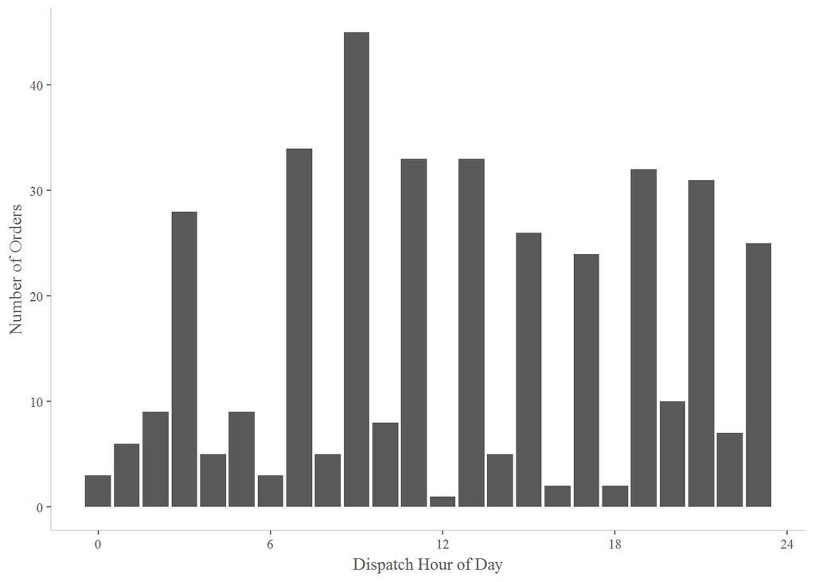

# Recommendation

All orders for vancomcyin levels should be placed using the Timed Study option, or Stat when appropriate.